# Chapter 3: Linear Regression

Notes from ISL

Sven Halvorson

### Definitions

3.1

- **Simple linear regression**: A technique where we model the model the output as having a straight line relationship with a single input $(Y\approx\beta_0+\beta_1X)$.
- **Residual**: The difference between an observed output and the corresponding prediction.
- **Residual sum of squares (RSS)**: The sum of the squares of all of the residuals for a fit of a linear model.
- **Standard error (SE)**: An estimate of the standard deviation of a statistic drawn from a sampling distribution.
- **Residual standard error (RSE)**: A summary measure of the sizes of errors made by a regression model. Given by $RSE = \sqrt{\frac{1}{n-k}\sum_{i=1}^n(y_i-\hat{y_i})^2}$
- **Correlation between $X$ and $Y$**: A measure of the strength of the linear relationships between two continuous variables. Defined as their covariance divided by the product of their standard deviations.

3.2

- **Partial effect**: The impact of a group of predictors on a regression model. Determined by an F-statistic by removing those variables from a model.
- **Variable selection**: Any process that choooses a set of predictors for a model.
- **Stepwise selection**: A variable selection method by which variables are added and/or removed from a model by some criteria until a stopping criteria is met.

3.3

- **Dummy variables**: A method of expanding a factor variable into a series of binary variables. Generally if the factor has $k$ levels then we expand to $k-1$ or $k$ dummy variables. These are sometimes called indicator variables in the mathematical context.
- **Main effects**: Coefficients attached to a single predictors.
- **Interaction effects**: Coefficients tied to products of two or more predictors.
- **Heteroscedasticity**: Non-constant variance across the support of a continuous predictor.
- **Weighted least squares**: A method of estimating the regression parameters by taking each observation to be the average of a number of observations. Used to value observations unequally.
- **Outlier**: A point with an unusually large/small response given their input values.
- **High leverage point**: An observation with an unusual combination of predictors. Often influences regression parameter estimates.
- **Collinearity**: When two or more observations are highly correlated/related.
- **Variance inflation factor**: A measurement that can be used to detect multicollinearity. Created by constructing a model where a particular predictor is set as the response to all others.

### Notes

#### 3.1: Simple linear regression

Here are the questions (given by the author) that linear regression is commonly used to address:

1. Is there a relationship between two variables?
2. If there is, how strong is it?
3. Which variables have relationships with an output?
4. How accurately can we estimate the relationships between inputs and outputs?
5. How accurately can we estimate outputs given inputs?
6. Is the relationship between inputs and outputs linear?
7. Is there synergy or disynergy among predictors?

The most basic regression is called *simple linear regresion* and uses only one predictor:

$$Y\approx\beta_0+\beta_1X$$

The betas are parameters often called *coefficients*. This is only the model, however, and when we estimate this relationship from actual data, we label the coefficients with hats to denote this. Here is the prediction for $Y$ given some value of $X=x$:

$$\hat{Y}\approx\hat\beta_0+\hat\beta_1x$$

Of course, any actual data set used will not fit a literal linear relationship and as a result there will be deviations from our predictions. If we fit a model and have a particular output, $y_i$, then it’s *residual* is:

$$\epsilon = y_i-\hat{y}$$

Although there are multiple methods of choosing $\beta_0$ and $\beta_1$, the most common is the method of *least squares*. This means we pick the values for those paramaters that minimize this quantity known as the *residual sum of squares*:

$$RSS = \sum_{i=1}^n{\epsilon_i^2}$$
$$RSS = \sum_{i=1}^n{(y_i-\beta_0-\beta_1x_i)^2}$$
The book has a nice 3D figure of the RSS as the vertical axis with the parameters as the depth and width. It’s like a valley where the nadir is the combination of $\beta_0$ and $\beta_1$ that produces the minimal RSS. I think I’ll try to reproduce some of the graphs that I like as I go through these notes but 3D takes too long.

There are nice formulas for $\beta_0$ and $\beta_1$ when there is only one predictor but with more inputs you start needing multivariable calculus and all that nasty partial derivative stuff.

The estimates for the coefficients are *unbiased* in that if the assumptions of the linear model are achieved, then they will not systematically over or under-estimate the ‘true’ values. The standard errors of the coefficients are measurements of how variable these estimates would be across various possible samples. If $\sigma^2$ is the variance of $Y$, then these standard errors can be computed as follows:

$$SE(\hat\beta_0)^2=\sigma^2\left[\frac{1}{n}+\frac{\bar{x}^2}{\sum_{i=1}^n(x_i-\bar{x})^2}\right]$$
$$SE(\hat\beta_1)^2=\frac{\sigma^2}{\sum_{i=1}^n(x_i-\bar{x})^2}$$
Let’s try to apply some logic to these to understand how they can potentially change. For both standard errors, having less variability in $Y$ will reduce the SE of these estimates. This makes some sense if we think about how these would be interpreted if we simply changed the units of $Y$, the standard errors would change just because of the scale change. For the intercept, we can see that increasing the sample size will make it so the contribution of $\frac{1}{n}$ becomes irrelevant. In both formulas, we see that having more variation in $X$ or more variation relative to it’s mean gives us smaller SE. To me this, makes some intuitive sense in that if we have a narrow bandwith for $X$, the results will be more unstable. It feels like having a wider range gives the data a better ability to develop a linear trend where as a shorter interval of $X$ might look more like a blob. We can do a quick simulation:

```r
# make two different data sets and truncate the inputs of one to a smaller range
set.seed(0)
df1 = tibble(
  x = runif(100),
  y = x + rnorm(100, sd = 0.1)
)

df2 = tibble(
  x = runif(500),
  y = x + rnorm(500, sd = 0.1)
) %>%
  filter(
    between(x, 0.25, 0.75)
  ) %>%
  sample_n(100)

# model both and get SE:
glm(
  y ~ x,
  data = df1
) %>%
  broom::tidy()
```

```
## # A tibble: 2 x 5
##   term        estimate std.error statistic  p.value
##   <chr>          <dbl>     <dbl>     <dbl>    <dbl>
## 1 (Intercept) -0.00570    0.0194    -0.293 7.70e- 1
## 2 x            0.993      0.0331    30.0   3.97e-51
```

```r
glm(
  y ~ x,
  data = df2
) %>%
  broom::tidy()
```

```
## # A tibble: 2 x 5
##   term         estimate std.error statistic  p.value
##   <chr>           <dbl>     <dbl>     <dbl>    <dbl>
## 1 (Intercept) -0.000278    0.0354  -0.00784 9.94e- 1
## 2 x            0.979       0.0688  14.2     1.39e-25
```

So that gives us about double standard error for the same sample size on half the interval.

They give a description of confidence intervals which I find a little off. It’s phrased in terms of having 95% probability of containing the true parameter value but this is not true for a particular confidence interval. In any case, they give the 95% confidence intervals as being approximately this:

$$\hat{\beta_i} \pm2\cdot SE(\beta_i)$$
Then they give a quick description of hypothesis tests and give the *t-statistic* as:

$$t =\frac{\hat\beta_i-\beta_{i, null}}{SE(\beta_i)}$$

Then the proportion of the t-distribution with the appropriate degrees of freedom that is more extreme in absolute value than $t$ is the *p-value*. This is then compared to a pre-specified threshold, generally named and chosen to be $\alpha=0.05$.

The authors give two measures of model fit which are the *residual standard error (RSE)* and the *coefficient of determination (*$R^2$*)*.

The RSE is a measure of fit in that it compares the predicted and observed values and then makes an average of sorts. Given $k$ predictors, the RSE should be:
$$RSE = \sqrt{\frac{1}{n-k}RSS}=\sqrt{\frac{1}{n-k}\sum_{i=1}^n(y_i-\hat{y_i})^2}$$
This measure of *lack of fit* gives us a way to summarize how far off our predictions were from the observed values. We should qualify what a large or small value of RSE in in terms of $Y$ which is a limitation of this. It can be used effectively though for comparing different models with the same output.

The other measure of fit given here is $R^2$ which, unlike RSE, does not have units and is defined like this:
$$R^2 = 1 - \frac{RSS}{TSS}=1-\frac{\sum_{i=1}^n(y_i-\hat{y_i})^2}{\sum_{i=1}^n(y_i-\bar{y_i})^2}$$
This is essentially saying ‘what proportion of the variance is explanable by our predictors?’ This is nicely kept from 0 to 1 which makes comparing $R^2$ across vastly different models easy. The authors say that low values can be attributable to either poor model fit and/or high inherant variance in $Y$. I’m not quite sure I understand this second piece. A large value for $\sigma^2$ could still be predicted well assuming that the correlation with $X$ is strong and the range of $X$ is sufficient. Perhaps they mean that relative to it’s mean that $Y$ is highly variable. This would indicate a non-linear trend and thus lack of fit.

Finally, they give the definition of *correlation* as:

$$Cor(X,Y) = \frac{Cov(X,Y)}{\sigma_x\sigma_y}=\frac{\sum_{i=1}^n(x_i-\hat{x})(y_i-\hat{y})}{\sqrt{\sum_{i=1}^n(x_i-\hat{x})^2\sum_{i=1}^n(y_i-\hat{y})^2}}$$
This is a measure of the strength of the linear relationship between two continuous variables. There are a number of limitations to this measurement but it is easy to interpret. It’s bound between -1 and 1 where values farther from zero indicate a stronger relationship. Positive values indicate a direct relationship and negative indicate an inverse relationship.

#### 3.2: Mulitple linear regression

The concept of simple linear regression is easily expanded to have more than one predictor. There are many motivations to do this but the two given by the authors seem satisfactory to me: create predictions using values of multiple predictors at once and allowing relationships between predictors to play out. A *multiple linear regression* model with $Y$ as a response and $p$ predictors can bet written as:

$$Y = \beta_0+\sum_{i=1}^p\beta_iX_i$$

We can interpret each of the $\beta_i$ in the same way as the simple linear model except here we qualify that the change in $Y$ for a one unit change in $X_i$ is qualified on constant values for each other $X_i$. In the case of two predictors, we could think of this as a regression plane (instead of line) but after that the geometry dissolves for most of us. The method of selecting estimates for each $\beta_i$ is also done by minimizing the residual sum of squares however it now requires some more fancy calculus and what not to do so.

The authors also give a brief description of *confounding* here as well without mentioning it by name.

We then move into some of the questions initially posed as motivation to do linear regression the first being ‘is there a relationship between the predictors and the response?’ To answer this, we use a hypothesis test that asks if at least one of the coefficients is non-zero. The null in that case is:
$$H_0:\beta_1 = \beta_2 = ... = \beta_p$$
And then the alternative is at least one $\beta_i$ non-zero for $0<i\leq p$. This hypothesis test is conducted by computing the *F-statistic*:

$$F=\frac{(TSS-RSS)/p}{RSS/(n-p-1)}$$

If the assumptions of the linear model are met, then the expected value of the denominator is $\sigma^2$. Under the null, the expected value of the numerator is also $\sigma^2$ so the test boils down to asking if the denominator is smaller than expected under the null aka $F>1$. Intuitively, we can think about the numerator as the average explained squares per predictor. The denominator is the unexplained sum of squares per observation minus the necessary lost observations due to estimating the model parameters.

As a refresher, the F-statistic can be thought of as a comparison of variances. The intuition behind this is that if $Y$ is a chi-squared random variable then

$$Y\sim\chi_{k}^2\rightarrow Y=\sum_{i=1}^kX_{i}^2$$
Where the $X_i$ are iid standard normals. This is very similar to a variance of any RV if we think about centering about its mean and scaling the standard deviation. If we take two chi-squared variables, divide by their degrees of freedom, and take their ratio, we’ll end up with an F-distribution:

$$X_1\sim\chi_{j}^2 \wedge X_k\sim\chi_{k}^2\rightarrow\frac{X_1/j}{X_2/k}\sim F_{j,k}$$
Here we can think of the observations as being the the individual normal distributions that make up the two chi-squares, $X_1$ and $X_2$. Then we compute their variances and take a ratio. If the variances of the two different processes are equal this ratio will be 1. To test the hypothesis $H_0:Var(X_1)=Var(X_2)$, we can compute the F-statistic and then compare to a critical value on the F-distribution. In the regression context, we’re essentially doing the same thing. It’s a comparison of how much better our regression model performs (numerator/ESS) vs. how much variation is still left after performing the regression (denominator/RSS). The authors point out that the relationship between the p-value of an F-statistic and the p-values of the predictors in the model is not direct. They give an example where the null hypothesis is true (all $\beta = 0$) but we have a large number of predictors. In this case we’re likely to make a number of type 1 errors despite no variables being truly associated with the response.

Sometimes we may choose to perform this kind of F-test when we wish to see if a particular set of say $q$ coefficients are collectively non-zero. This hypothesis test is essentially:

$$H_0:\beta_{k-q+1}=\beta_{k-q}=...=\beta_q$$
Then the F-statistic is computed by fitting the model with all of the predictors as well as the model without these $q$ predictors and comparing the reduction in RSS to the RSS in the full model. If RSS$_0$ is the RSS from the model without the $q$ predictors in question then:

$$F=\frac{(RSS-RSS_0)/q}{RSS/(n-p-1)}$$
This kinda like saying ‘what if we didn’t include those $q$ predictors?’ Would you be sorry since your RSS is much larger with their omission? These are sometimes called the *partial effect* of adding those $q$ predictors. I see this most often when we’re considering categorical variables and interaction terms where we want to consider a number of levels of a predictor as a whole.

After determining that you have at least one predictor worth using, we might want to know if there are any worth discarding or others we didn’t use that actively help. The process of selecting a set of predictors is called *variable selection*. With $p$ predictors, there are a total of $2^p$ possible models that can be made so trying them all is not feasible. Instead, there are various algorithms and metrics that can be used to choose an ‘optimal’ selection of predictors. The authors assure us that we’ll return to this but here just introduce three general stepwise techniques:

- **Forward selection** starts with a model with no predictors and adds the predictor that reduces the RSS by the largest amount. This process is repeated until some stopping criteria is met. This is a greedy algorithm and as a result may include redundant variables that could be replaced by synergies of other variables.
- **Backward selection** starts with all of the possible predictors and then sequentially removes the one that has the largest p-value until all variables have a p-value under a pre-specified threshold. This cannot be performed when $n < p$ but I suspect this is rarely a problem in practice.
- **Mixed selection** is a combination of the previous two. We start with no predictors and add them to the model by some criteria like largest decrease to RSS. If at any step, the p-value of a variable rises beyond a particular level, we then remove that until all p-values are under a certain level and variables not included would have a large p-value if not in the model. The authors claim this fixes some of the issues of forward selection by removing variables that initially seem strong but are weaker in the presence of other variables.

These methods always made me think of some kind of regression cage match where the predictors have to fight for their right to join or stay in a model.

The final consideration given is about predictions. We are again reminded that there is an idea of a population plane which would be the set of coefficients that have the smallest sum of square errors for the entire set of possible measurements. The degree to which any estimate of this plane is off is reducible error that more data and better formulations of the model could reduce. The degree to which a multiple regression estimate misrepresents the true phenomena is the model bias. Even if the true $f$ was close to linear, we would still make errors in our predictions due to the exact sample that we have. As a result, we generally compute confidence intervals about $\hat{Y}$ to represent our uncertanty

#### 3.3: Other considerations in the regression model

The final set of points made here are mostly about ways in which multiple regression can be extended to fit other circumstances and the ways in which it can fail/flail.

The first consideration is how to incorporate factor variables into a regression model. This is generally done but *dummy variables*; a process where we convert factors into a series of binary variables. There are several flavors of this but the most common is to choose one as a reference category and compare each other to that. If we had the variable $X$ as either treatment or control then we can make a new variable $X'$ as:
$$X'=
\begin{cases}
0, & x_i = \text{control} \\
1, & x_i = \text{treatment}
\end{cases}$$
In this case the estimated $\beta$ for $X$ is the change in outcome when we change from control to treatment. This is nice when there is an obvious comparison we want to make. Alternatively, we can make the intercept the global mean and then have the dummies coded to be deviations from this mean:

$$X'=
\begin{cases}
-1, & x_i = \text{control} \\
1, & x_i = \text{treatment}
\end{cases}$$
I don’t really like this system as much but it has its uses. When we go to more than two levels then we start to need more dummy variables. The reference category schema extends to needing one fewer dummy than levels in the categorical variable. If we had two treatments, say A and B, then we could make these dummies:
$$X_1'=
\begin{cases}
0, & x_i = \text{control} \\
1, & x_i = \text{treatment A}
\end{cases}$$
$$X_2'=
\begin{cases}
0, & x_i = \text{control} \\
1, & x_i = \text{treatment B}
\end{cases}$$
In addition to using categorical predictors, we can also relax the *additive assumption*. This means that we’re no longer restricting ourselves to only computing a weighted average of each factor. Instead, we can add what’s known as an *interaction term* which is the product of two or more factors:

$$Y = \beta_0 + \beta_1X_1 + \beta_2X_2 + \beta_3X_1X_2 + \epsilon$$
The interpretation of $\beta_3$ is the additional effect of $X_1$ and $X_2$ beyond their isolated effect. Interpreting it more precisely depends a bit on whether each of the other predictors are continuous ore categorical.

- When both are binary, $\beta_3$ is the added ‘bonus’ of when $X_1=X_2=1$
- When one is binary and the other is continuous, $\beta_3$ is the change in slope between the two lines formed by the continuous predictor and each level of the binary. It allows for the relationship between a continuous predictor and the outcome to vary across levels of a categorical variable.
- When both are continuous and we increase the value of one predictor by 1 unit, this will change Y by an amount that depends on the value of the other predictor. In this case, the surface created by the regression model feels a little less ‘linear’ in the sense that it’s not flat anymore.

These types of terms are especially helpful when we think that there may be synergy or antagonism between the variables. It’s also used in situations where we may want to test the effect of a variable across several subgroups. The authors give the *hierarchical principle* which suggests that whenever interactions are found useful, their main effects should also be left in the model regardless of their independent power to predict $Y$.

Another extension of a multiple linear regression model is *polynomial* regression where we powers of variables to account for nonlinear relationships between predictors and responses. An example of this might to do a quadratic regression like this:

$$Y = \beta_0 + \beta_1X +\beta_2X^2$$
In this form, a one unit change in $X$ does not linearly change $Y$. Instead, the exact amount that $Y$ changes by is dependent on the actual value that $X$ changes from. As a result, interpreting these models is more challenging but they can fit the data better. In my experience, it seems very rare that you will want to have more than a cubic term in these models. Adding too many polynomial terms seriously risks overfitting the data. I also think if you’re trying to get some visual feel of the trend something like a loess smoother will do the job better.

The last portion of this chapter is just about some problems that you can encounter when using linear regression. One is that if we try to model the wrong shape of association, then we will encounter additional bias. For example, using only additive terms will not work out very well if the relationship between a continuous predictor and outcome is more like a U shape. In this case, residual plots can detect this problem. A possible solution includes adding powers/logs/roots of predictors to accomodate the non-linearity.

Another issue is that the error terms are sometimes correlated. The most common association is that that the sign or magnitude of $\epsilon_i$ has some relationship with the sign of $\epsilon_{i+1}$. Common examples of this are trends through time where the previous day’s measurement is indicative of today’s measurement. This is sometimes called *tracking*. In truth, it doesn’t have to just be a relationship between ‘adjacent’ values. Correlation between errors can be broader and more strange in its manifestations.

The principle consequence of *correlated data* is that the standard errors are too small and thus the predictions will appear overly confident. A way to think of this is that we essentially have less data than we would if the observations were independent. The example given is that if you just duplicated your data set it will shrink all of your confidence intervals but there is not actually any more data to support this. There are a number of methods to mitigate this problem such as random terms. ` Another potential problem is non-constant variance of the response across levels/ranges of the predictors. This is a problem because the assumptions of how confidence intervals are created depend on this. It can be detected through residual plots where a funnel shape may emerge (although other patterns can be indicative of this problem). An example of this might be if you were modeling the sales of stores as a function of the area of their building we might find this pattern. A large store can have bigger fluctuations in its sales since they can potentially accommodate more customers. Conversely, a small shop may be constrained by their building and thus sell approximately the same amount regardless of other trends. The problem of *heteroscedasticity* (wild word) can be mitigated by transformations that unevenly change the values of observations such as logs. Another method which I had not heard of is weighting observations by the inverse of the variance for that level of predictor.

Two similar problems that can ocurr are *outliers* and *high leverage points*. Both of these refer to particular observations in the data set that have some unusually large influence on either the parameter estimates or model fit. The difference between these two ideas was a bit confusing for me when I first saw them but the book does a great job of illustrating how a high leverage point is a special kind of outlier (my words). Outliers have the feature that they are very dissimilar to the rest of the points in either the value of one of their predictors or the outcome value. While they often don’t affect the regression estimates that much, outliers can dramatically affect the measures of model fit such as MSE and $R^2$. My personal preference is to leave outliers in the model unless there is good evidence that they are recording errors.

High leverage points, on the other hand, don’t have extreme values in the response for their inputs. Instead, they either have extreme values for the predictor(s). The authors give a very nice example here of how certain combinations of variables that don’t follow the overall trend can be high leverage points even if none of the predictor values are extreme in themselves. Unlike outliers, high leverage points can have a dramatic inpact on the regression parameters. As a result, they are more troublesome. A measure of this is the leverage statistic. For simple linear regression, the $i^th$ observation’s leverage statistic is:

$$h_i=\frac{1}{n}+\frac{(x_i-\bar{x})^2}{\sum_{i'=0}^n(x_{i'}-\bar{x})^2}$$
It’s not clear here but I believe that the $i'$ here is re-indexing the data set to exclude the $i^th$ observation. So this formula is kinda like the fraction of the total sum of squares that the $i^th$ observation represents. We’re told that this is bounded between $\frac{1}{n}$ and 1, that the average leverage is $\frac{p+1}{n}$.

The last issue discussed is *collinearity* which is an issue surrounding relationships between predictors. They give an excellent example plot here that shows how the coefficient estimates for two parameters can be highly sensitive to the changing data if they are highly correlated themselves. Let’s see if we can do a little simulation here to prove this point:

```r
# first make two variables that are reasonably well correlated
# as our response and primary predictor:
set.seed(0)
population_table = tibble(
  X1 = runif(n = 1000),
  Y = X1 + rnorm(n = 1000, sd = 0.3)
)

# Now add in two potential covariates, one correlated with
# Y only and one correlated with both X1 and Y
population_table = population_table %>%
  mutate(
    X2 = 0.25*Y + rnorm(n = 1000, sd = 0.3),
    X3 = 0.25*Y + rnorm(n = 1000, sd = 0.3) + X1,
    across(
      everything(),
      function(x){(x-min(x))/(max(x)-min(x))}
    )
  ) %>%
  relocate(Y)

cor(population_table)
```

```
##            Y        X1        X2        X3
## Y  1.0000000 0.6759196 0.3129061 0.6352684
## X1 0.6759196 1.0000000 0.1906274 0.7840040
## X2 0.3129061 0.1906274 1.0000000 0.1871927
## X3 0.6352684 0.7840040 0.1871927 1.0000000
```

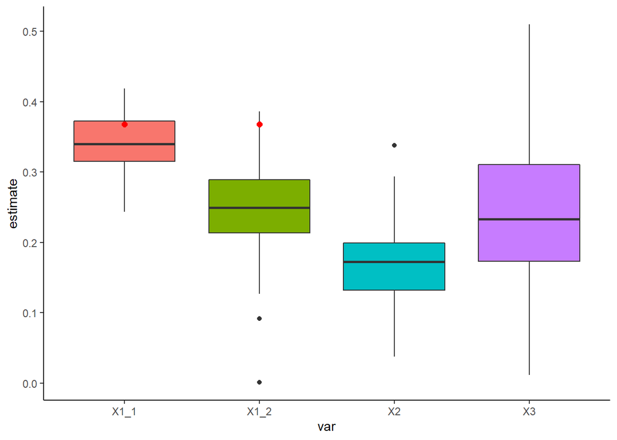

```r
# so we have some moderate orrelation between X1 & X2 and a stronger relationship
# with X1 & X3

# Sample repeatedly:
sample_params = function(irrelevant){

  samp = population_table %>%
    sample_n(size = 100)

  mod1 = glm(
    formula = Y ~ X1 + X2,
    data = samp,
    family = 'gaussian'
  )

  mod2 = glm(
    formula = Y ~ X1 + X3,
    data = samp,
    family = 'gaussian'
  )

  tibble(
    X1_1 = coefficients(mod1)[2],
    X2 = coefficients(mod1)[3],
    X1_2 = coefficients(mod2)[2],
    X3 = coefficients(mod2)[3]
  )

}

samples = (1:100) %>%
  lapply(sample_params) %>%
  bind_rows()

# univariate population values for comparison:
make_uni = function(x){

  coef = glm(
    as.formula(paste0('Y + ', x)),
    data = population_table,
    family = 'gaussian'
  ) %>%
    coefficients()

  tibble(
    var = x,
    estimate = coefficients(coef)[2]
  )

}

population_param = glm(
  formula = Y ~ X1,
  data = population_table,
  family = 'gaussian'
) %>%
  coefficients() %>%
  .[[2]]

samples %>%
  pivot_longer(
    cols = everything(),
    names_to = 'var',
    values_to = 'estimate'
  ) %>%
  ggplot(
    aes(x = var, y = estimate, fill = var)
  ) +
  geom_boxplot() +
  geom_point(
    data = tibble(
      var = c('X1_1', 'X1_2'),
      estimate = population_param
    ),
    color = 'red',
    size = 2
  ) +
  theme_classic() +
  theme(legend.position = 'none')
```

```r
var(samples$X1_1)
```

```
## [1] 0.001561872
```

```r
var(samples$X1_2)
```

```
## [1] 0.00414468
```

The fact that the estimates for X1_1 are closer to the univariate estimate is not the point here but we can see that the width of the boxplot for X1_2 is a bit larger than for X1_1. The variences of estimates are a fair bit different as well.

A couple additional notes on collinearity are given. First, because it increases the uncertainty of estimates for our regression estimates, the standard errors of those correlated variables will be larger. As a result, our statistical power decreases.

Secondly, there are a few ways to try and detect collinearity. We can look at correlation matrices but as the authors note, sometimes problems occur through relationships of more than two variables (*multicollinearity*). Another method is to look at the *variance inflation factor* (VIF) for each variable. To compute the variance inflation factor for a predictor $X_j$, set it as the response in a model with all the other predictors. Then the $R^2$ from this model is used in this formula:
$$VIF(\hat{\beta_j}) = \frac{1}{1-R_{X_j|X_{-j}}^2}$$
So basically the more that the other predictors can predict $X_j$, the smaller the denominator is and thus the larger $VIF(\hat{\beta_j})$ is. Often thresholds of 5 or 10 are given which would correspond to an $R^2$ of 0.8 or 0.9. This seems a bit high to me but my personal experience is that we often want to throw in a bunch of other variables. Maybe these thresholds are just here to identify the most extreme multicollinearity. The simulation I previously did does not fit either of these thresholds.

### 3.5 Comparing linear regression with k-nearest neighbors

A simple modification can be made to the k-nearest neighbors alogrithm for classification discussed in chapter 2 in order to handle the case of a continuous outcome. Given an observation we want to predict, $x_0$, the KNN regression selects the K nearest values to $x_0$ (by some metric) and puts them into a set $\mathcal{N}_0$. Then we average the responses of all the observations in $\mathcal{N}_0$:

$$\text{KNN regression estimate} = \hat{f}(x_0)=\frac{1}{K}\sum_{x_i\in\mathcal{N}_0}y_i$$

I am not quite sure about the history of this but I suspect this was invented later than linear regression. It seems substantially more intuitive as you’re just saying ‘let’s just average all the closest observations to $x_0$!’ The book visualizes this as some kind of 3D step function where there are a bunch of shelves like Q-bert. The steps get smaller as K gets larger as a small change in $x_0$ is more likely to change $\mathcal{N}_0$ if we draw on a greater number of points. Personally, I had envisioned this more like soap bubbles (Bayes decision boundary) where each bubble determines the set of inputs that are mapped to the same prediction. I’m sure they get into this a bit later but it seems difficult to choose K for these algorithms which seems like an analogous problem to selecting variables for multiple linear regression.

The two major points of comparison they make when comparing linear and KNN regression: considerations about the linearity of $f$ and issues surrounding the number of predictors. In the case that the true predictor response is roughly linear, linear regression generally performs better. This is because there is very little to be gained from the low bias in the KNN regression. The variance of the more flexible KNN method can cause overfitting that is not helpful in the case of a roughly linear $f$. On the other hand, when there start to be larger deviations from linearity, KNN starts to perform better, especially when a good choice of K is made. Even with some modifications, such as polynomial terms, linear regression will fail to accommodate many non-linear scenarios.

The second consideration is the number of predictors used. Assuming we have a reasonable observation to predictor ratio, linear regression performs fine if we throw in a bunch of irrelevant predictors. Sure, they eat up some degrees of freedom but this doesn’t really make our predictions that much worse since irrelevant predictors get small coefficients and thus don’t affect the predictions much. Conversely, adding a lot of nonsense variables to a KNN regression model will weaken the model. This is because it does not give any preference to particular variables in terms of selecting $\mathcal{N}_0$. We can imagine having 19 very weak predictors and 1 strong predictor but if we compute Euclidean distances, the 1 good predictor just gets an equal share in that calculation. This issue is called the *curse of dimensionality* where we’re overwhelmed by the number of predictors and lose accuracy as a result.

Lastly, they mention that the interpretability of linear regression is much higher. I know that the focus of this book is not on inference but for me, this is the biggest reason to use linear regression.